# DS 202 Lab 3

Emma Smykalski

3/5/2021

[output not shown]

[output not shown]

[output not shown]

```r
dat1 <- dat %>%
  rename(
    year = `Gss year for this respondent`,
    hap = `General happiness`,
    attend = `How often r attends religious services`,
    polparty = `Political party affiliation`,
    fammoney = `How many in family earned money`,
    sex = `Respondents sex`,
    school = `Highest year of school completed`,
    children = `Number of children`,
    marriage = `Marital status`,
    id = `Respondent id number`,
    ballot = `Ballot used for interview`
    )
```

```r
dat1$school <- as.integer(dat1$school)
dat1 <- dat1 %>% drop_na()
```

## Exploration

### 1)

It looks like those who are never married and divorced have the highest average years of school. Never married makes sense being the group with the highest average school because I think a lot of people don’t get married if they are very focused on school and their career.

```r
edu <- dat1 %>% filter(marriage != 'No answer') %>%
  group_by(marriage) %>%
  summarize(aveschool = mean(school)) %>%
  arrange(desc(aveschool))
edu
```

```
## # A tibble: 5 x 2
##   marriage      aveschool
##   <chr>             <dbl>
## 1 Never married      13.4
## 2 Divorced           13.1
## 3 Married            13.0
## 4 Separated          11.9
## 5 Widowed            11.2
```

### 2)

```r
betteredu <- dat1 %>%
  group_by(marriage) %>%
  filter(school > mean(school))
str(betteredu)
```

```
## tibble [30,714 x 11] (S3: grouped_df/tbl_df/tbl/data.frame)
##  $ year    : num [1:30714] 1972 1972 1972 1972 1972 ...
##  $ hap     : chr [1:30714] "Not too happy" "Not too happy" "Pretty happy" "Not too happy" ...
##  $ attend  : chr [1:30714] "Once a year" "Never" "Once a year" "Never" ...
##  $ polparty: chr [1:30714] "Ind,near dem" "Not str democrat" "Ind,near dem" "Ind,near dem" ...
##  $ fammoney: chr [1:30714] "1" "2" "1" "1" ...
##  $ sex     : chr [1:30714] "Female" "Female" "Male" "Male" ...
##  $ school  : int [1:30714] 16 17 14 16 13 14 14 17 14 13 ...
##  $ children: chr [1:30714] "0" "0" "0" "0" ...
##  $ marriage: chr [1:30714] "Never married" "Married" "Never married" "Never married" ...
##  $ id      : num [1:30714] 1 4 6 8 11 16 17 19 20 23 ...
##  $ ballot  : chr [1:30714] "Not applicable" "Not applicable" "Not applicable" "Not applicable" ...
##  - attr(*, "groups")= tibble [6 x 2] (S3: tbl_df/tbl/data.frame)
##   ..$ marriage: chr [1:6] "Divorced" "Married" "Never married" "No answer" ...
##   ..$ .rows   : list<int> [1:6]
##   .. ..$ : int [1:3414] 23 41 56 77 166 208 250 304 334 378 ...
##   .. ..$ : int [1:16040] 2 5 6 7 8 10 11 12 14 15 ...
##   .. ..$ : int [1:6250] 1 3 4 9 13 17 21 22 25 28 ...
##   .. ..$ : int [1:14] 9288 10465 11676 13143 22339 22935 22950 22986 23943 26304 ...
##   .. ..$ : int [1:1458] 43 44 51 89 107 108 128 141 156 221 ...
##   .. ..$ : int [1:3538] 47 76 81 87 99 103 113 115 122 125 ...
##   .. ..@ ptype: int(0)
##   ..- attr(*, ".drop")= logi TRUE
```

### 3)

In order to see how marriage status and happiness are related I created a new column (IsHappy) which assigned “Happy” to people who said they were either “very happy” or “pretty happy” and assigned “Other” to the rest of the respondents. From here I took the total number “Happy” people in each marital group and divided by the total number of people in that group to make my variable “happyrate.” From my arranged output of dat7, I found that married people had the highest rate of happiness and seperted people had the lowest rate. My plot further emphasizes this.

```r
dat5 <- dat1 %>%
  mutate(IsHappy = ifelse(hap == 'Pretty happy' |
                            hap == 'Very happy',
                          'Happy',
                          'Other'))

dat6 <- dat5 %>% group_by(marriage) %>%
  summarize(n = n(), sumofhappy = sum(IsHappy == 'Happy'))

dat7 <- dat6 %>% filter(marriage != 'No answer') %>%
  mutate(happyrate = sumofhappy/n) %>%
  arrange(desc(happyrate))
dat7
```

```
## # A tibble: 5 x 4
##   marriage          n sumofhappy happyrate
##   <chr>         <int>      <int>     <dbl>
## 1 Married       34053      29285     0.860
## 2 Never married 13801      10665     0.773
## 3 Widowed        6164       4649     0.754
## 4 Divorced       8363       6169     0.738
## 5 Separated      2233       1482     0.664
```

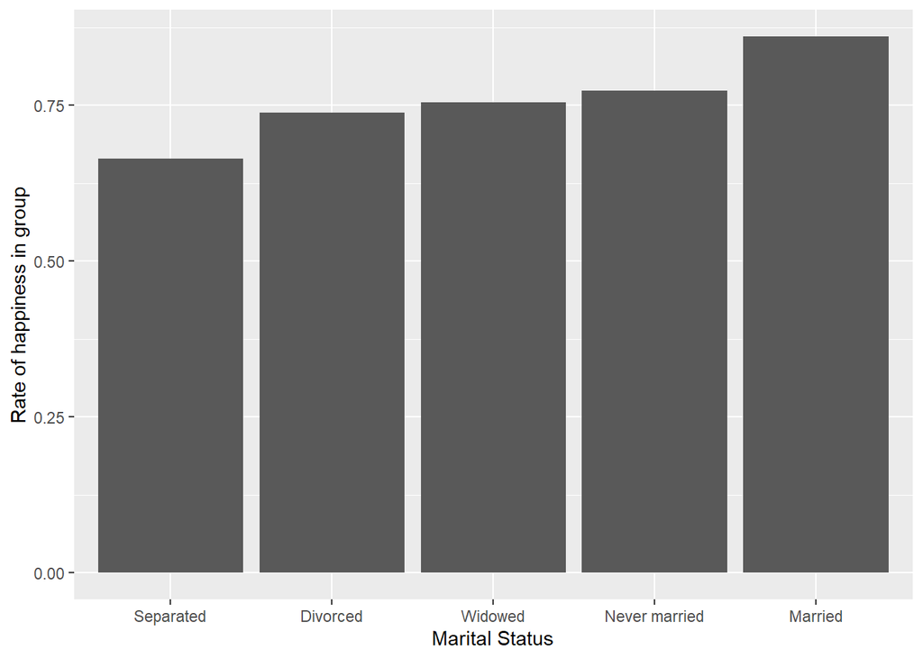

```r
ggplot(dat7, aes(x=reorder(marriage, happyrate),weight = happyrate)) + geom_bar() + ylab('Rate of happiness in group') + xlab('Marital Status')
```

### 4)

I found that party affiliation does affect the relationship between marriage and happiness. From my faceted plot you can see that the political parties that had the most amount of happy people were not strong democrats and not strong republicans. In the plot for each of these two parties you can see that the marital status that had the most happy people were those who were married. This shows that there is a large amount of not strong democrats and not strong republics who are married and are happy. I also defined a rate of happiness variable (rateofhappy) to summarize the rate of happy people in each combination of political party and marriage status. I arranged those rates and found that the top four happies combinations of political party and marriage status are (married,not strong republican), (married, independent near republican), (married, not strong democrat), and (married, strong republican.) (I ignored the “Don’t know” political party)

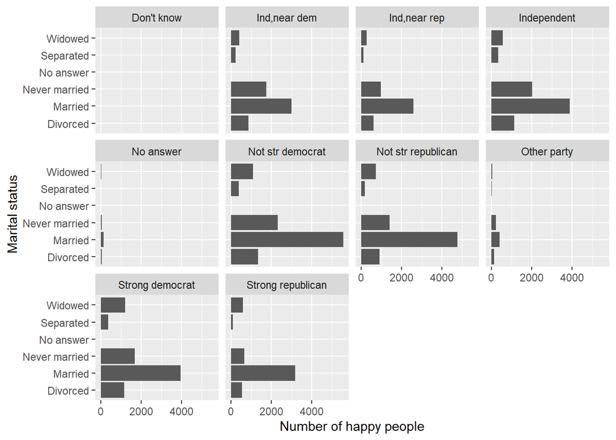

```r
ggplot(dat5, aes(x=marriage, weight = mean(IsHappy=='Happy'))) + geom_bar() + facet_wrap(~polparty) + coord_flip() +xlab('Marital status')+ ylab('Number of happy people')
```

```r
dat13 <- dat5 %>% filter(marriage != 'No answer') %>%
  group_by(marriage, polparty) %>%
  summarize(frequency = n(), rateofhappy = sum(IsHappy == 'Happy')/frequency) %>%
  arrange(desc(rateofhappy))
dat13
```

```
## # A tibble: 49 x 4
## # Groups:   marriage [5]
##    marriage      polparty           frequency rateofhappy
##    <chr>         <chr>                  <int>       <dbl>
##  1 Married       Don't know                 6       1
##  2 Married       Not str republican      5909       0.888
##  3 Married       Ind,near rep            3223       0.876
##  4 Married       Not str democrat        6880       0.866
##  5 Married       Strong republican       3933       0.865
##  6 Married       Other party              523       0.860
##  7 Married       Ind,near dem            3717       0.860
##  8 Married       Strong democrat         4880       0.849
##  9 Never married Not str republican      1754       0.822
## 10 Married       Independent             4803       0.816
## # ... with 39 more rows
```

### 5)

I didn’t find much of a relationship between marital status and education. When I found the mean years of schooling in each marital status group I found that they were all fairly similar. I made a boxplot to visually represent this and you can see that their medians all lie between around 11 and 14 (disregarding the “no answer” group.)

```r
eduvsmar <- dat1 %>% filter(marriage != 'No answer') %>%
  group_by(marriage) %>%
  summarize(meanedu = mean(school))
eduvsmar
```

```
## # A tibble: 5 x 2
##   marriage      meanedu
## * <chr>           <dbl>
## 1 Divorced         13.1
## 2 Married          13.0
## 3 Never married    13.4
## 4 Separated        11.9
## 5 Widowed          11.2
```

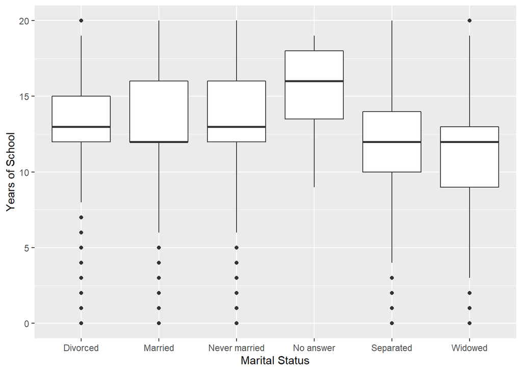

```r
ggplot(dat1, aes(x=marriage, y=school)) + geom_boxplot() + ylab('Years of School') + xlab('Marital Status')
```

### 6)

The two other questions that I wanted to explore were how the number of children and martial status effect the happiness of someone and also how the frequency of which someone goes to church is related to the level of education of that individual. First lets look at how children and marital status effect happiness:  
I made a side-by-side histogram of the number of happy people (from IsHappy) based off of the number of children and the marital status. I found that the group that had the highest number of happy people were those who were married and had two kids. The group that had the second highest number of happy people were never married individuals with no kids. It looks like seperated people with any amount of kids had the lowest number of happy people.

```r
dat9 <- dat5 %>% filter(attend != 'Dk,na', marriage != 'No answer', IsHappy == 'Happy')
dat9$children <- as.numeric(dat9$children)
```

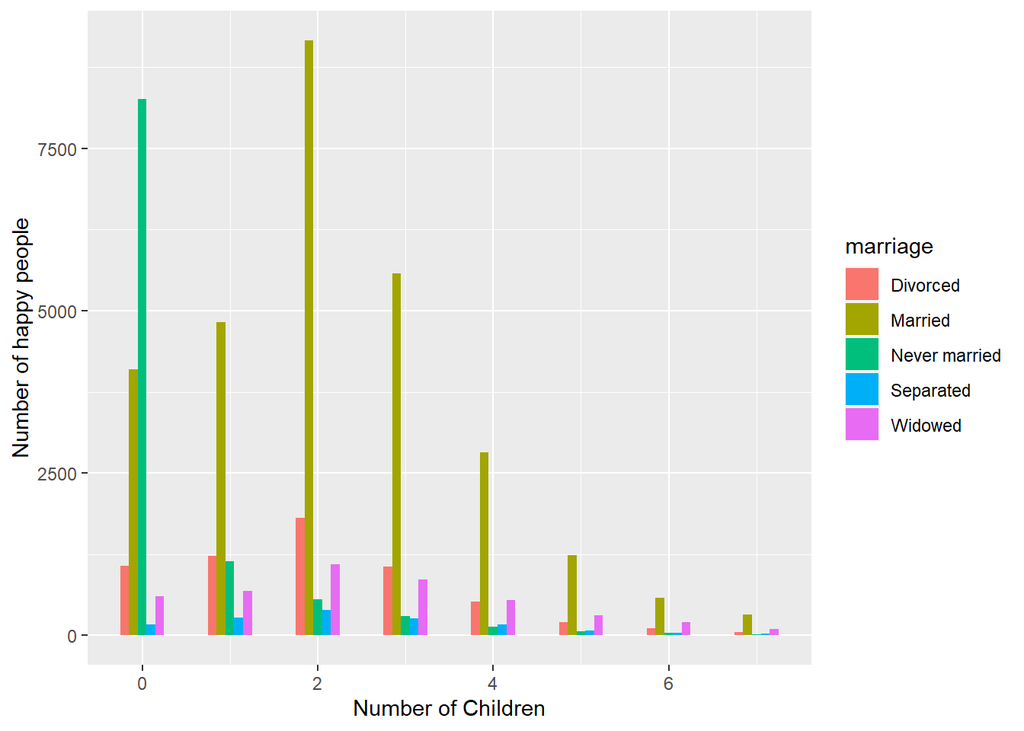

```r
ggplot(dat9, aes(x=children, fill=marriage)) + geom_histogram(binwidth = 1/2, position = 'dodge') + xlab('Number of Children') + ylab('Number of happy people')
```

For my numerical summary of this I just looked at how the number of children effect happiness by finding the rate of happy people per each group of number of children. I found that the happiest people have 2 or 0 kids.

```r
dat11 <- dat5 %>% filter(children != 'Dk na') %>% group_by(children) %>%
  summarize(n=n(), sumofhappy = sum(IsHappy == 'Happy'), happyrate = sumofhappy/n) %>%
  arrange(desc(happyrate))
dat11
```

```
## # A tibble: 9 x 4
##   children          n sumofhappy happyrate
##   <chr>         <int>      <int>     <dbl>
## 1 2             16041      13138     0.819
## 2 0             17621      14318     0.813
## 3 4              5218       4209     0.807
## 4 3             10079       8112     0.805
## 5 6              1229        985     0.801
## 6 1             10276       8215     0.799
## 7 5              2391       1907     0.798
## 8 Eight or more   938        735     0.784
## 9 7               673        526     0.782
```

Now let’s look at how the frequency of which someone goes to church is related to the level of education of that individual:  
I found that there is not much of a relationship between these two factors, the average school for each frequency of going to church is between 12.5 and 13. The group with the lowest average years of schooling is those who attend church more than once a week.

```r
dat12 <- dat1 %>% select(attend,school) %>% filter(attend != 'Dk,na') %>%
  group_by(attend) %>%
  summarize(averageschool = mean(school)) %>%
  arrange(desc(averageschool))
dat12
```

```
## # A tibble: 9 x 2
##   attend           averageschool
##   <chr>                    <dbl>
## 1 Once a year               13.0
## 2 Once a month              13.0
## 3 Sevrl times a yr          13.0
## 4 Every week                13.0
## 5 2-3x a month              12.9
## 6 Never                     12.8
## 7 Nrly every week           12.8
## 8 Lt once a year            12.7
## 9 More thn once wk          12.5
```

I also made a boxplot of the years of schooling for each group and you can see how there is not much of a relationship in this visual representation.

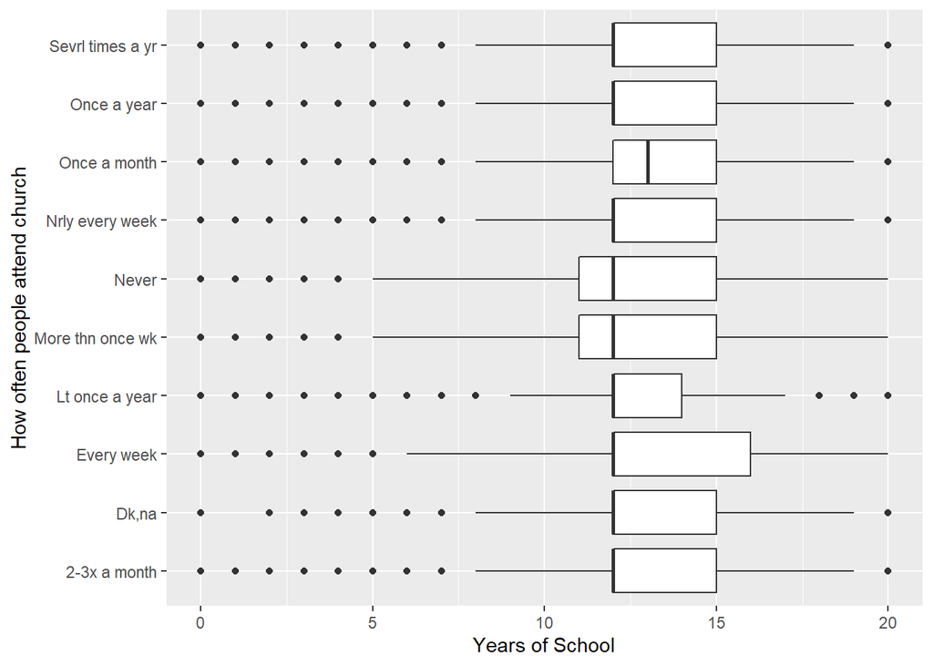

```r
ggplot(dat1, aes(x=attend, y=school)) + geom_boxplot() + ylab('Years of School') + xlab('How often people attend church') + coord_flip()
```